# Simple Linear Regression: Assumptions

Recall that the simple linear regression model for $Y$ on $x$ is
$$Y=\beta_0+\beta_1 x+\epsilon$$
where

$Y$ : the dependent or response variable

$x$ : the independent or predictor variable, assumed known

$\beta_0,\beta_1$ : the regression parameters, the intercept and slope of the regression line

$\epsilon$ : the random regression error around the line.

and the regression equation for a set of $n$ data points is $\hat{y}=b_0+b_1\;x$, where
$$b_1=\frac{S_{xy}}{S_{xx}}=\frac{\sum
(x_i-\bar{x})(y_i-\bar{y})}{\sum (x_i-\bar{x})^2}$$
and
$$b_0=\bar{y}-b_1\; \bar{x}$$
where $b_0$ is called the **y-intercept** and $b_1$ is called the **slope**.

The **residual standard error** $s_e$ can be defined as

$$s_e=\sqrt{\frac{SSE}{n-2}}=\sqrt{\frac{\sum(y_i-\hat{y}_i)^2}{n-2}}$$
$s_e$ indicates how much, on average, the observed values of the response variable differ from the predicated values of the response variable. $~$

## Simple Linear Regression Assumptions (SLR)

We have a collection of $n$ pairs of observations $\{(x_i,y_i)\}$, and the idea is to use them to estimate the unknown parameters $\beta_0$ and $\beta_1$.
$$\epsilon_i=Y_i-(\beta_0+\beta_1\;x_i)\;,\;\;i=1,2,\ldots,n$$

We need to make the following key assumptions on the errors:

A. $E(\epsilon_i)=0$ (errors have mean zero and do not depend on $x$)

B. $Var(\epsilon_i)=\sigma^2$ (errors have a constant variance, homoscedastic, and do not depend on $x$)

C. $\epsilon_1, \epsilon_2,\ldots \epsilon_n$ are independent.

D. $\epsilon_i \mbox{ are all i.i.d. } N(0, \;\sigma^2)$, meaning that the errors are independent and identically distributed as Normal with mean zero and constant variance $\sigma^2$.

The above assumptions, and conditioning on $\beta_0$ and $\beta_1$, imply:

1. Linearity: $E(Y_i|X_i)=\beta_0+\beta_1\;x_i$
2. Homogenity or homoscedasticity: $Var(Y_i|X_i)=\sigma^2$
3. Independence: $Y_1,Y_2,\ldots,Y_n$ are all independent given $X_i$.
4. Normality: $Y_i|X_i\sim N(\beta_0+\beta_1x_i,\;\sigma^2)$

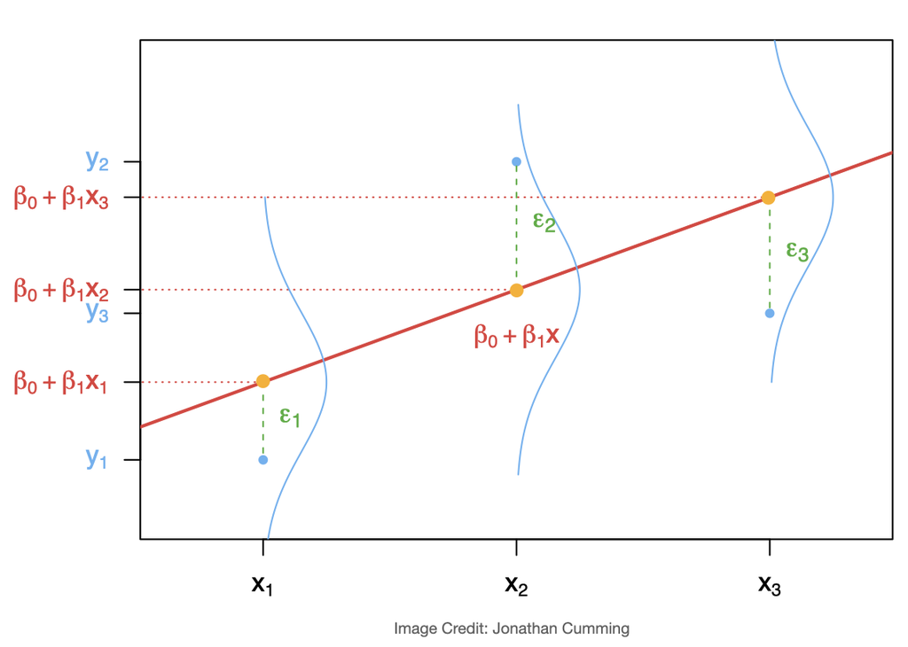

## Example: used cars (cont.)

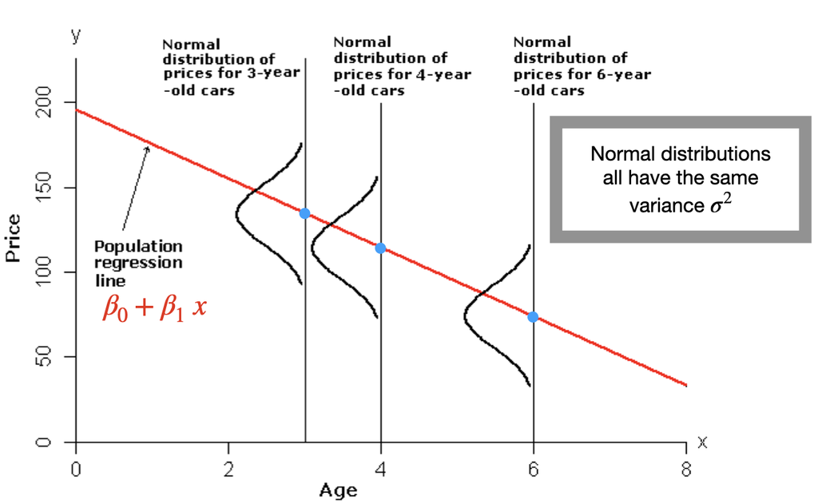

We can see that for each age, the mean price of all cars of that age lies on the regression line $E(Y|x)=\beta_0+\beta_1x$. And, the prices of all cars of that age are assumed to be normally distributed with mean equal to $\beta_0+\beta_1 x$ and variance $\sigma^2$. For example, the prices of all 4-year-old cars must be normally distributed with mean $\beta_0+\beta_1 (4)$ and variance $\sigma^2$.

We used the least square method to find the best fit for this data set, and residuals can be obtained as $e_i=y_i-\hat{y_i}= y_i-(195.47 -20.26x_i)$.

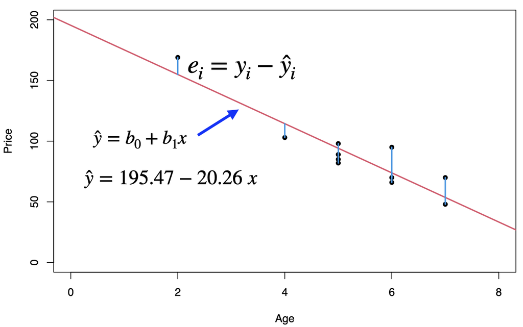

## Residual Analysis

The easiest way to check the simple linear regression assumptions is by constructing a scatterplot of the residuals ($e_i=y_i-\hat{y_i}$) against the fitted values ($\hat{y_i}$) or against $x$. If the model is a good fit, then the **residual plot** should show an even and random scatter of the residuals.

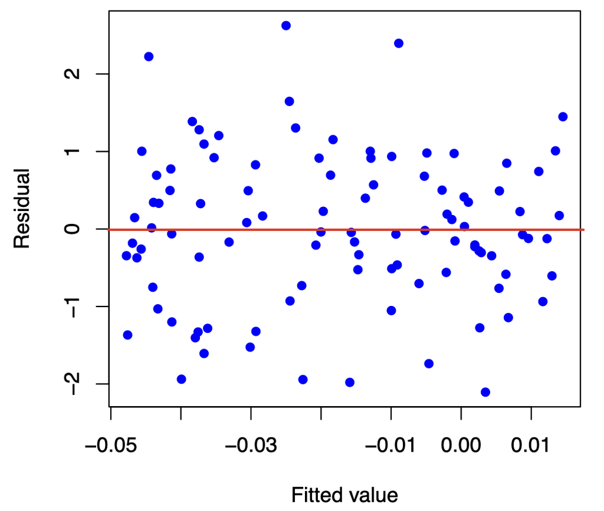

### Linearity

The regression needs to be linear in the parameters.

$$Y=\beta_0+\beta_1\;x+\epsilon$$
$$E(Y_i|X_i)=\beta_0+\beta_1\;x_i \equiv
E(\epsilon_i|X_i)=E(\epsilon_i)=0$$

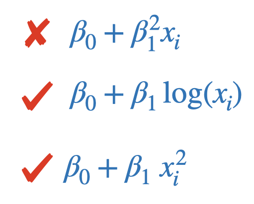

The residual plot below shows that a linear regression model is not appropriate for this data.

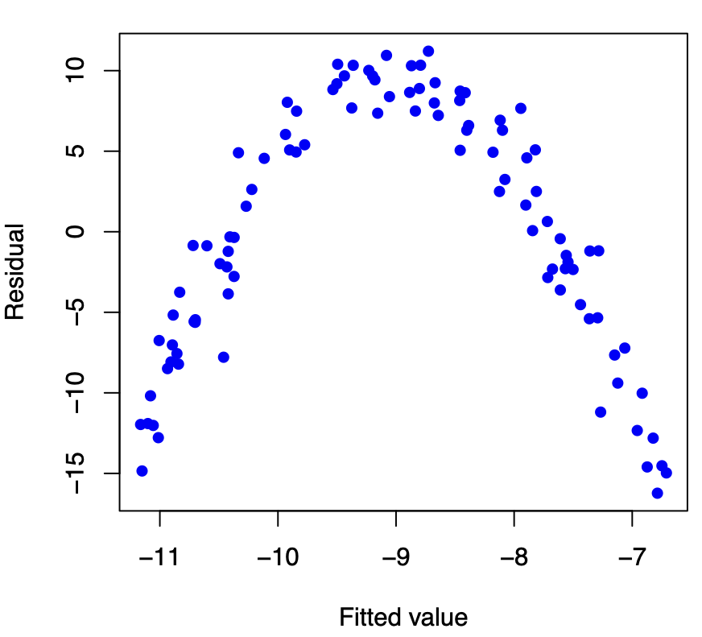

### Constant error variance (homoscedasticity)

The plot shows the spread of the residuals is increasing as the fitted values (or $x$) increases, which indicates that we have Heteroskedasticity (non-constant variance). The standard errors are biased when heteroskedasticity is present, but the regression coefficients will still be unbiased.

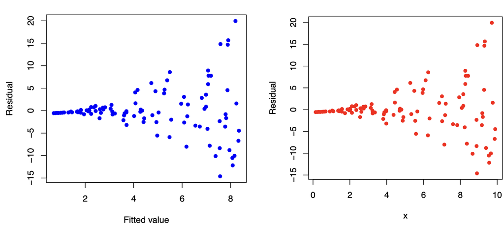

**How to detect?**

- Residuals plot (fitted vs residuals)
- Goldfeld–Quandt test
- Breusch-Pagan test

**How to fix?**

- White’s standard errors
- Weighted least squares model
- Taking the log

### Independent errors terms (no autocorrelation)

The problem of autocorrelation is most likely to occur in time series data, however, it can also occur in cross-sectional data, e.g. if the model is incorrectly specified. When autocorrelation is present, the regression coefficients will still be unbiased, however, the standard errors and test statitics are no longer valid.

**An example of no autocorrelation**

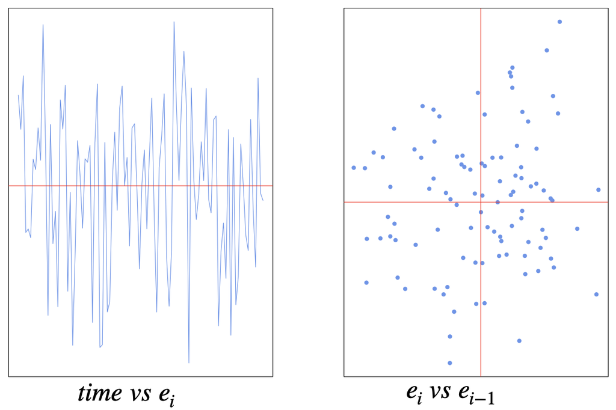

**An example of positive autocorrelation**

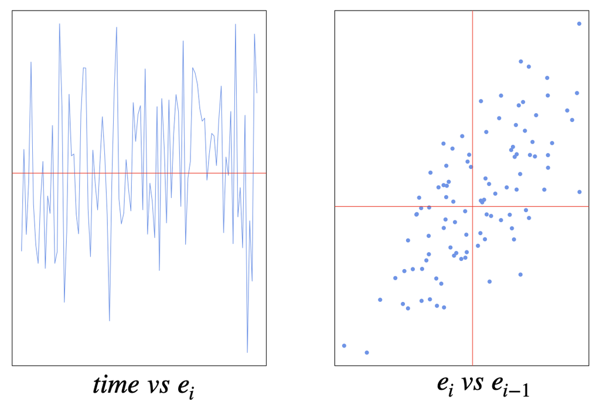

**An example of negative autocorrelation**

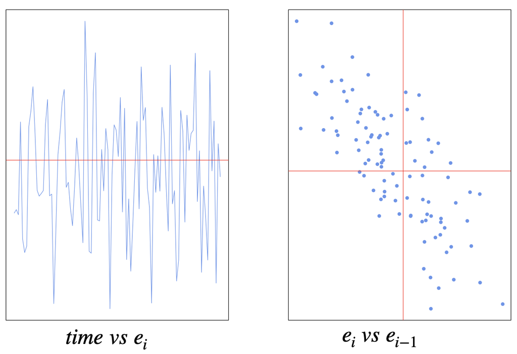

**How to detect?**

- Residuals plot
- Durbin-Watson test
- Breusch-Godfrey test

**How to fix?**

- Investigate omitted variables (e.g. trend, business cycle)
- Use advanced models (e.g. AR model)

### Normality of the errors

We need the errors to be normally distributed. Normality is only required for the sampling distributions, hypothesis testing and confidence intervals.

**How to detect?**

- Histogram of residuals
- Q-Q plot of residuals
- Kolmogorov–Smirnov test
- Shapiro–Wilk test

**How to fix?**

- Change the functional form (e.g. taking the log)
- Larger sample if possible

## Example: Infant mortality and GDP

```r
# install.packages("carData")
library(carData)
data(UN)
options(scipen=999)
# Remove missing data
newUN<-na.omit(UN)
str(newUN)
```

```
## 'data.frame':    193 obs. of  7 variables:
##  $ region         : Factor w/ 8 levels "Africa","Asia",..: 2 4 1 1 5 2 3 8 4 2 ...
##  $ group          : Factor w/ 3 levels "oecd","other",..: 2 2 3 3 2 2 2 1 1 2 ...
##  $ fertility      : num  5.97 1.52 2.14 5.13 2.17 ...
##  $ ppgdp          : num  499 3677 4473 4322 9162 ...
##  $ lifeExpF       : num  49.5 80.4 75 53.2 79.9 ...
##  $ pctUrban       : num  23 53 67 59 93 64 47 89 68 52 ...
##  $ infantMortality: num  124.5 16.6 21.5 96.2 12.3 ...
##  - attr(*, "na.action")= 'omit' Named int [1:20] 4 6 21 35 38 54 67 75 77 78 ...
##   ..- attr(*, "names")= chr [1:20] "American Samoa" "Anguilla" "Bermuda" "Cayman Islands" ...
```

```r
fit<- lm(infantMortality ~ ppgdp, data=newUN)
summary(fit)
```

```
##
## Call:
## lm(formula = infantMortality ~ ppgdp, data = newUN)
##
## Residuals:
##    Min     1Q Median     3Q    Max
## -31.48 -18.65  -8.59  10.86  83.59
##
## Coefficients:
##               Estimate Std. Error t value             Pr(>|t|)
## (Intercept) 41.3780016  2.2157454  18.675 < 0.0000000000000002 ***
## ppgdp       -0.0008656  0.0001041  -8.312   0.0000000000000173 ***
## ---
## Signif. codes:  0 '***' 0.001 '**' 0.01 '*' 0.05 '.' 0.1 ' ' 1
##
## Residual standard error: 25.13 on 191 degrees of freedom
## Multiple R-squared:  0.2656, Adjusted R-squared:  0.2618
## F-statistic: 69.08 on 1 and 191 DF,  p-value: 0.0000000000000173
```

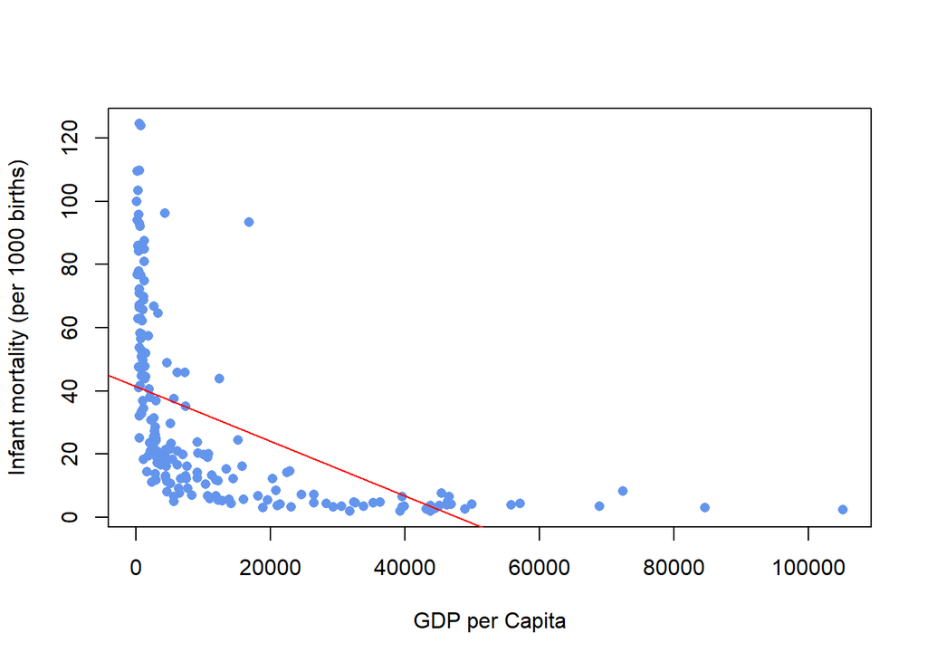

```r
plot(newUN$infantMortality ~ newUN$ppgdp, xlab="GDP per Capita", ylab="Infant mortality (per 1000 births)", pch=16, col="cornflowerblue")
abline(fit,col="red")
```

We can see from the scatterplot that the relationship between the two variables is not linear. There is a concentration of data points at small values of GDP (many poor countries) and a concentration of data points at small values of infant mortality (many countries with very low mortality). This suggests a skewness to both variables which would not conform to the normality assumption. Indeed, the regression line (the red line) we construct is a poor fit and only has an $R^2$ of 0.266.

From the residual plot below we can see a clear evidence of structure to the residuals suggesting the linear relationship is a poor description of the data, and substantial changes in spread suggesting the assumption of homogeneous variance is not appropriate.

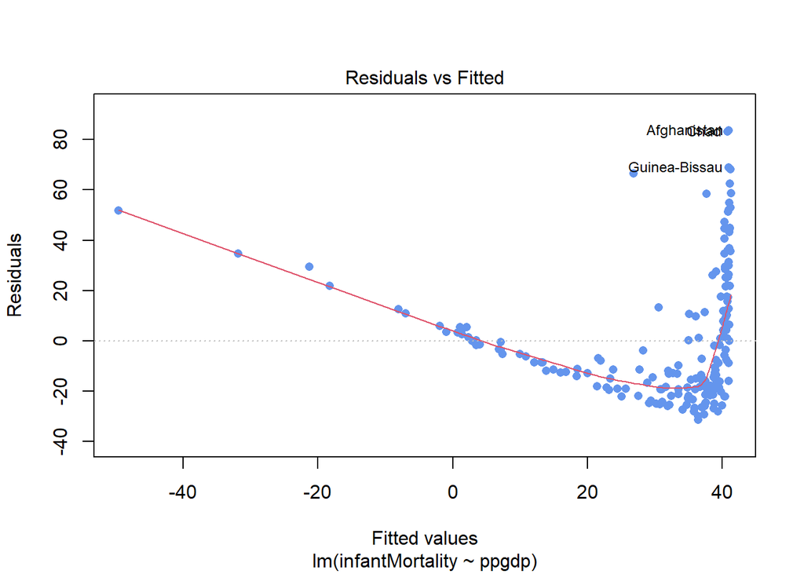

```r
# diagnostic plots
plot(fit,which=1,pch=16,col="cornflowerblue")
```

So we can apply a transformation to one or both variables, e.g. taking the log or adding a quadratic form. Notice that this will not affect (violet) the linearity assumption as the regression will still be linear in the parameters. So if we take the logs of both variables gives us the scatterplot of the transformed data set, below, which appears to show a more promising linear structure. The quality of the regression is now improved, with an $R^2$ value of 0.766, which is still a little weak due to the rather large spread in the data.

```r
fit1<- lm(log(infantMortality) ~ log(ppgdp), data=newUN)
summary(fit1)
```

```
##
## Call:
## lm(formula = log(infantMortality) ~ log(ppgdp), data = newUN)
##
## Residuals:
##      Min       1Q   Median       3Q      Max
## -1.16789 -0.36738 -0.02351  0.24544  2.43503
##
## Coefficients:
##             Estimate Std. Error t value            Pr(>|t|)
## (Intercept)  8.10377    0.21087   38.43 <0.0000000000000002 ***
## log(ppgdp)  -0.61680    0.02465  -25.02 <0.0000000000000002 ***
## ---
## Signif. codes:  0 '***' 0.001 '**' 0.01 '*' 0.05 '.' 0.1 ' ' 1
##
## Residual standard error: 0.5281 on 191 degrees of freedom
## Multiple R-squared:  0.7662, Adjusted R-squared:  0.765
## F-statistic: 625.9 on 1 and 191 DF,  p-value: < 0.00000000000000022
```

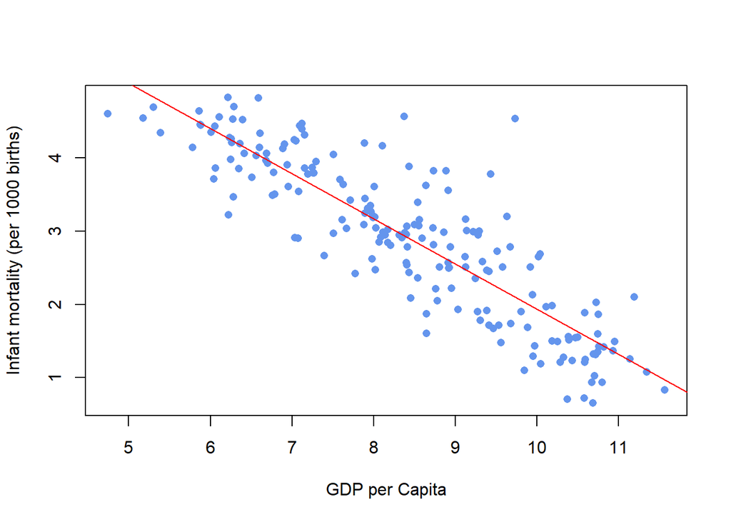

```r
plot(log(newUN$infantMortality) ~ log(newUN$ppgdp), xlab="GDP per Capita", ylab="Infant mortality (per 1000 births)", pch=16, col="cornflowerblue")
abline(fit1,col="red")
```

So we check the residuals again, as we can see from the residuals plot below that the log transformation has corrected many of the problems with with residual plot and the residuals now much closer to the expected random scatter.

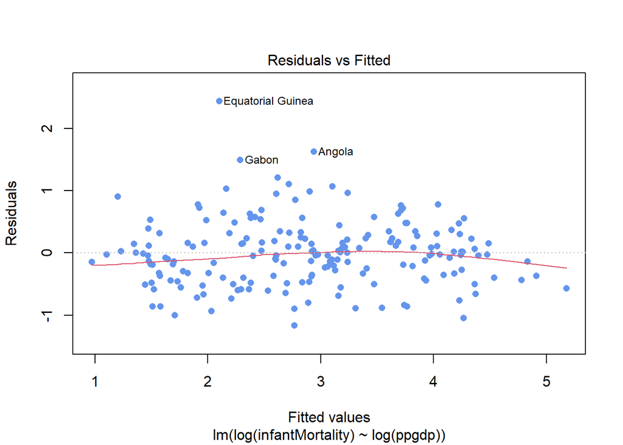

```r
# diagnostic plots
plot(fit1,which=1,pch=16,col="cornflowerblue")
```

Now let us check the Normality of the errors by creating a histogram and normal QQ plot for the residuals, before and after the log transformation. The normal quantile (QQ) plot shows the sample quantiles of the residuals against the theoretical quantiles that we would expect if these values were drawn from a Normal distribution. If the Normal assumption holds, then we would see an approximate straight-line relationship on the Normal quantile plot.

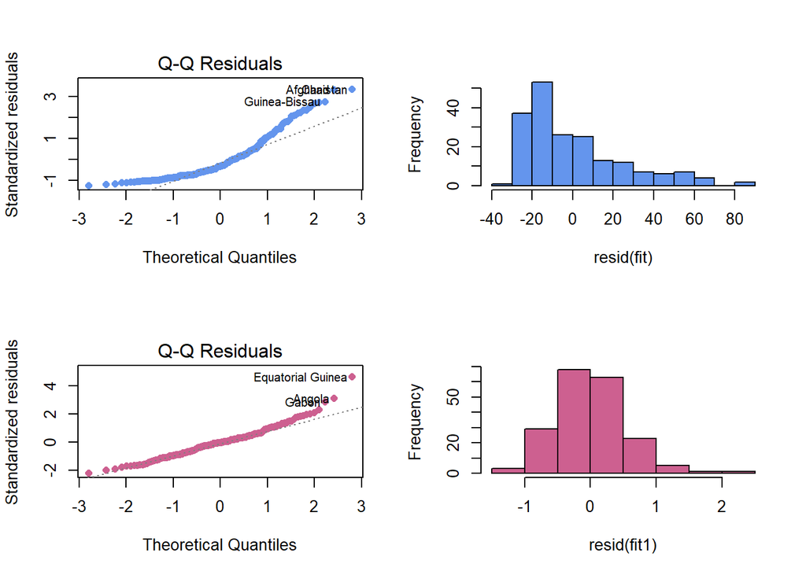

```r
par(mfrow=c(2,2))
# before the log  transformation.
plot(fit, which = 2,pch=16, col="cornflowerblue")
hist(resid(fit),col="cornflowerblue",main="")
# after the log  transformation.
plot(fit1, which = 2, pch=16, col="hotpink3")
hist(resid(fit1),col="hotpink3",main="")
```

The normal quantile plot and the histogram of residuals (before the log transformation) shows strong departure from the expectation of an approximate straight line, with curvature in the tails which reflects the skewness of the data. Finally, the normal quantile plot and the histogram of residuals suggest that residuals are much closer to Normality after the transformation, with some minor deviations in the tails.